# Mobile Game analysis

# 1 Introduction

We will be looking at some game data to explore retention and user tutorial completion rate.

### 1.1 Loading libraries

```r
#Loading libraries. We need jsonlite here to import the json formatted dataset.
library(jsonlite)
library(dplyr)
library(ggplot2)
library(tidyr)
library(ggthemes)
```

### 1.2 Intitial observations

We see a lot of incorrect classes, missing variables in install.date, and a strange looking time variable.

```r
head(run)
```

```
## Source: local data frame [6 x 7]
##
##   app_version  game          type          event  user install.date
##         (chr) (int)         (chr)          (chr) (int)        (chr)
## 1       1.0.7  3368 session_start             NA 35862           NA
## 2       1.0.7  3368          user             NA 35862     20151124
## 3       1.0.7  3368         event tutorial.start 35862           NA
## 4       1.0.7  3368         event       startRun 35862           NA
## 5       1.0.7  3368          user             NA 35862     20151124
## 6       1.0.7  3368         event   tutorial.end 35862           NA
## Variables not shown: time (dbl)
```

```r
str(run)
```

```
## Classes 'tbl_df', 'tbl' and 'data.frame':    53474 obs. of  7 variables:
##  $ app_version : chr  "1.0.7" "1.0.7" "1.0.7" "1.0.7" ...
##  $ game        : int  3368 3368 3368 3368 3368 3368 3368 3368 3368 3368 ...
##  $ type        : chr  "session_start" "user" "event" "event" ...
##  $ event       : chr  NA NA "tutorial.start" "startRun" ...
##  $ user        : int  35862 35862 35862 35862 35862 35862 35862 35862 35862 35862 ...
##  $ install.date: chr  NA "20151124" NA NA ...
##  $ time        : num  1.45e+12 1.45e+12 1.45e+12 1.45e+12 1.45e+12 ...
```

# 2 Data cleaning

We have some work to do here. We’ll need to adjust a few classes to factors and dates. We will also change game type to represent iOS or Android.

```r
#Change a few columns to factors % use iOS or Android for column game
run <-
run %>%
  mutate(
    game = ifelse(game == "3368", "iOS", "Android")
  ) %>%
  mutate_each(funs(as.factor),
            c(app_version,
              game,
              type,
              event)
  )

#Let's confirm the changes
str(run)
```

```
## Classes 'tbl_df', 'tbl' and 'data.frame':    53474 obs. of  7 variables:
##  $ app_version : Factor w/ 11 levels "","1.0.7","1.0.8",..: 2 2 2 2 2 2 2 2 2 2 ...
##  $ game        : Factor w/ 2 levels "Android","iOS": 2 2 2 2 2 2 2 2 2 2 ...
##  $ type        : Factor w/ 5 levels "currency_given",..: 4 5 2 2 5 2 2 2 2 2 ...
##  $ event       : Factor w/ 43 levels "boostUsed","dailyGiftClaimed",..: NA NA 40 18 NA 33 41 42 36 38 ...
##  $ user        : int  35862 35862 35862 35862 35862 35862 35862 35862 35862 35862 ...
##  $ install.date: chr  NA "20151124" NA NA ...
##  $ time        : num  1.45e+12 1.45e+12 1.45e+12 1.45e+12 1.45e+12 ...
```

### 2.1 Missing install dates

There a lot of missing install dates. It looks like because the install date is logged only when certain events are logged. We will use the match funtion to pair user and their install date and then update the original dataset.

```r
#Map install dates
matchrun <-
run %>%
  distinct(user, install.date) %>%
  filter(!is.na(install.date)) %>%
  select(user, install.date)

matchrun
```

```
## Source: local data frame [760 x 2]
##
##     user install.date
##    (int)        (chr)
## 1  35862     20151124
## 2  47472     20151124
## 3   9762     20151124
## 4  57267     20151124
## 5  29943     20151124
## 6  58406     20151124
## 7  32575     20151124
## 8  39181     20151124
## 9   6121     20151124
## 10 18864     20151124
## ..   ...          ...
```

```r
#Mapping to original dataset
run$installed <- matchrun$install.date[match(run$user, matchrun$user)]

#Verification of install.date and installed
run %>%
  select(user, installed, install.date) %>%
  filter(!is.na(install.date)) %>%
  distinct(user, installed) %>%
  print(n=10)
```

```
## Source: local data frame [756 x 3]
##
##     user installed install.date
##    (int)     (chr)        (chr)
## 1  35862  20151124     20151124
## 2  47472  20151124     20151124
## 3   9762  20151124     20151124
## 4  57267  20151124     20151124
## 5  29943  20151124     20151124
## 6  58406  20151124     20151124
## 7  32575  20151124     20151124
## 8  39181  20151124     20151124
## 9   6121  20151124     20151124
## 10 18864  20151124     20151124
## ..   ...       ...          ...
```

Let’s drop the install.date column that’s full of NAs and also make the newly created installed column a date class.

```r
run <-
  run %>%
  select(-install.date) %>%
  mutate(
    installed = as.Date(installed, format = "%Y%m%d")
  )
```

### 2.2 Unix time

Remember that weird time variable? Looks like it’s unix time so we’ll have to have R convert it to a readable time.

```r
#Convert unix to Los Angeles time
run <-
run %>%
  mutate_each(funs(as.POSIXct(run$time/1000, origin="1970-01-01", tz="AMERICA/LOS_ANGELES")), time)

run %>%
  select(user, time)
```

```
## Source: local data frame [53,474 x 2]
##
##     user                time
##    (int)              (time)
## 1  35862 2015-11-24 08:11:03
## 2  35862 2015-11-24 08:11:03
## 3  35862 2015-11-24 08:12:14
## 4  35862 2015-11-24 08:12:32
## 5  35862 2015-11-24 08:12:32
## 6  35862 2015-11-24 08:14:33
## 7  35862 2015-11-24 08:14:33
## 8  35862 2015-11-24 08:14:33
## 9  35862 2015-11-24 08:14:33
## 10 35862 2015-11-24 08:14:33
## ..   ...                 ...
```

Now that we have a proper time let’s seperate date and time and give them the correct class.

```r
#Separate date and time
run <-
run %>%
  separate(time, c("date", "time"), sep = " ")

#Make the date column a date class
run$date <- as.Date(run$date)
run$installed <- as.Date(run$installed, format = "%Y%m%d")

run %>%
  select(user, date, time)
```

```
## Source: local data frame [53,474 x 3]
##
##     user       date     time
##    (int)     (date)    (chr)
## 1  35862 2015-11-24 08:11:03
## 2  35862 2015-11-24 08:11:03
## 3  35862 2015-11-24 08:12:14
## 4  35862 2015-11-24 08:12:32
## 5  35862 2015-11-24 08:12:32
## 6  35862 2015-11-24 08:14:33
## 7  35862 2015-11-24 08:14:33
## 8  35862 2015-11-24 08:14:33
## 9  35862 2015-11-24 08:14:33
## 10 35862 2015-11-24 08:14:33
## ..   ...        ...      ...
```

```r
#Filter only marketing days ECHO OFF
run <-
  run %>%
  filter(installed >= "2015-12-05" & installed <= "2015-12-10")
```

# 3 Retention

Now our data is ready lets look into retention!

### 3.1 Preparing data for retention analysis

We need to a format where the dataset will give us the user, their first install date, and their subsequent logins. Day0 represents the count of users.

```r
#Create columns marking if users are 0 or 1 for logging in that day
retentionOG <-
run %>%
  mutate(
    day0 = as.integer(ifelse(date - installed == 0, 1, 0)),
    day1 = as.integer(ifelse(date - installed == 1, 1, 0)),
    day2 = as.integer(ifelse(date - installed == 2, 1, 0)),
    day3 = as.integer(ifelse(date - installed == 3, 1, 0)),
    day4 = as.integer(ifelse(date - installed == 4, 1, 0)),
    day5 = as.integer(ifelse(date - installed == 5, 1, 0)),
    day6 = as.integer(ifelse(date - installed == 6, 1, 0)),
    day7 = as.integer(ifelse(date - installed == 7, 1, 0))
  )

head(retentionOG) %>%
  select(user, installed, day0:day7)
```

```
## Source: local data frame [6 x 10]
##
##    user  installed  day0  day1  day2  day3  day4  day5  day6  day7
##   (int)     (date) (int) (int) (int) (int) (int) (int) (int) (int)
## 1 48719 2015-12-05     0     0     0     0     0     0     0     0
## 2 48719 2015-12-05     0     0     0     0     0     0     0     0
## 3 48719 2015-12-05     0     0     0     0     0     0     0     0
## 4 48719 2015-12-05     0     0     0     0     0     0     0     0
## 5 48719 2015-12-05     0     0     0     0     0     0     0     0
## 6 48719 2015-12-05     0     0     0     0     0     0     0     0
```

By collapsing the rows we can get a total count of how many users installed the game on a certain day and the sebsequent visits from day 1 to day 7

```r
#Using summarise_each sum collapse the rows based on the installation date of user.
retention <-
retentionOG %>%
  group_by(installed) %>%
  distinct(user, date) %>%
  summarise_each(funs(sum), contains("day"))
retention
```

```
## Source: local data frame [6 x 9]
##
##    installed  day0  day1  day2  day3  day4  day5  day6  day7
##       (date) (int) (int) (int) (int) (int) (int) (int) (int)
## 1 2015-12-05    96    22    15     8     5     1     5     2
## 2 2015-12-06    90    15     5     6     9     5     7     5
## 3 2015-12-07    50     6     4     2     5     4     0     3
## 4 2015-12-08    76    17    11     4     5     3     1     4
## 5 2015-12-09    20     4     2     3     1     2     0     0
## 6 2015-12-10    16     3     2     0     3     2     1     1
```

For graphical purposes let’s change the numbers to percentages.

```r
#Change to percentages
retention.p <-
  retention %>%
  mutate(
    d0 = round(day0 / day0, 2),
    d1 = round(day1 / day0, 2),
    d2 = round(day2 / day0, 2),
    d3 = round(day3 / day0, 2),
    d4 = round(day4 / day0, 2),
    d5 = round(day5 / day0, 2),
    d6 = round(day6 / day0, 2),
    d7 = round(day7 / day0, 2)
  ) %>%
  select(installed, day0, d1:d7)

#Changing nan to 0s. a[is.nan(a)] <- 0 doesn't work with dataframes
is.nan.data.frame <- function(x)
  do.call(cbind, lapply(x, is.nan))

retention.p[is.nan(retention.p)] <- 0

retention.p
```

```
## Source: local data frame [6 x 9]
##
##    installed  day0    d1    d2    d3    d4    d5    d6    d7
##       (date) (int) (dbl) (dbl) (dbl) (dbl) (dbl) (dbl) (dbl)
## 1 2015-12-05    96  0.23  0.16  0.08  0.05  0.01  0.05  0.02
## 2 2015-12-06    90  0.17  0.06  0.07  0.10  0.06  0.08  0.06
## 3 2015-12-07    50  0.12  0.08  0.04  0.10  0.08  0.00  0.06
## 4 2015-12-08    76  0.22  0.14  0.05  0.07  0.04  0.01  0.05
## 5 2015-12-09    20  0.20  0.10  0.15  0.05  0.10  0.00  0.00
## 6 2015-12-10    16  0.19  0.12  0.00  0.19  0.12  0.06  0.06
```

### 3.2 Plotting

Let’s prepare for two graphs. A bar and a point/line.

```r
retention.plot <-
retention.p %>%
  gather(day, retention, d1:d7) %>%
  arrange(installed, day)

retention.plot
```

```
## Source: local data frame [42 x 4]
##
##     installed  day0   day retention
##        (date) (int) (chr)     (dbl)
## 1  2015-12-05    96    d1      0.23
## 2  2015-12-05    96    d2      0.16
## 3  2015-12-05    96    d3      0.08
## 4  2015-12-05    96    d4      0.05
## 5  2015-12-05    96    d5      0.01
## 6  2015-12-05    96    d6      0.05
## 7  2015-12-05    96    d7      0.02
## 8  2015-12-06    90    d1      0.17
## 9  2015-12-06    90    d2      0.06
## 10 2015-12-06    90    d3      0.07
## ..        ...   ...   ...       ...
```

Here is the bar representation of retention

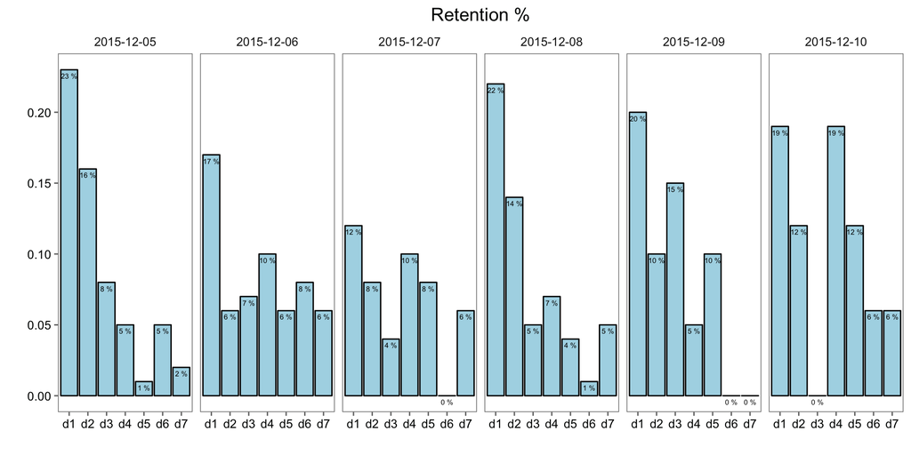

```r
#Bar graph
ggplot(retention.plot, aes(x = day, y = retention, label = paste(100*(retention), '%'))) +
  geom_bar(stat = "identity", fill = "light blue", color = "black") +
  facet_grid(~installed) +
  theme_few() +
  geom_text(vjust = 1.7, size = 2) +
  ggtitle("Retention %") +
  ylab("") +
  xlab("")
```

And now the point/line represention

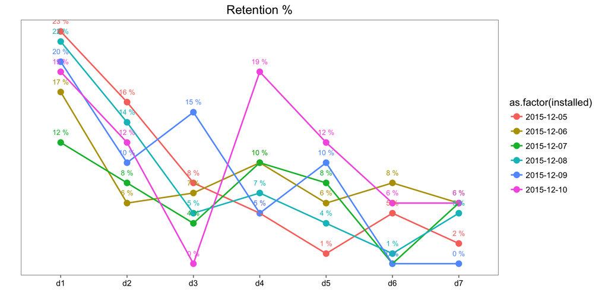

```r
#Line graph
ggplot(retention.plot, aes(x = day, y = retention, color = as.factor(installed), label = paste(100*retention, '%'), group = installed)) +
  geom_point(size = 3) +
  geom_line(size = .8) +
  theme_few() +
  scale_fill_few() +
  geom_text(size = 3, vjust = -1.5) +
  ggtitle("Retention %") +
  ylab("") +
  xlab("") +
  theme(
    axis.ticks.y = element_blank(),
    axis.text.y = element_blank()
  )
```

### 3.3 Plotting for android vs iOS

Is there a difference in retention for platforms? There could possible be a bug on one platform that affects retention. Let’s graph to check like we did above.

```r
#Retention by platform and use additional parameter group_by for game
retention.by.platform <-
  retentionOG %>%
  group_by(installed, game) %>%
  distinct(user, date) %>%
  summarise_each(funs(sum), contains("day"))

#Create percentages
retention.by.platform.p <-
  retention.by.platform %>%
  mutate(
    day0p = round(day0 / day0, 2),
    d1 = round(day1 / day0, 2),
    d2 = round(day2 / day0, 2),
    d3 = round(day3 / day0, 2),
    d4 = round(day4 / day0, 2),
    d5 = round(day5 / day0, 2),
    d6 = round(day6 / day0, 2),
    d7 = round(day7 / day0, 2)
  ) %>%
  select(installed, game, day0, d1:d7)

#Changing nan to 0s. a[is.nan(a)] <- 0 doesn't work with dataframes
is.nan.data.frame <- function(x)
  do.call(cbind, lapply(x, is.nan))

retention.by.platform.p[is.nan(retention.by.platform.p)] <- 0
```

Before we go check the graph let’s take a quick view the count of users for each platform

```r
#Table of how many from each platform
retention.by.platform %>%
  group_by(game) %>%
  summarise(
    count = sum(day0)
  )
```

```
## Source: local data frame [2 x 2]
##
##      game count
##    (fctr) (int)
## 1 Android   195
## 2     iOS   153
```

```r
#Plotting
retention.by.platform.plot <-
  retention.by.platform.p %>%
  gather(day, retention, d1:d7) %>%
  arrange(installed, day)
```

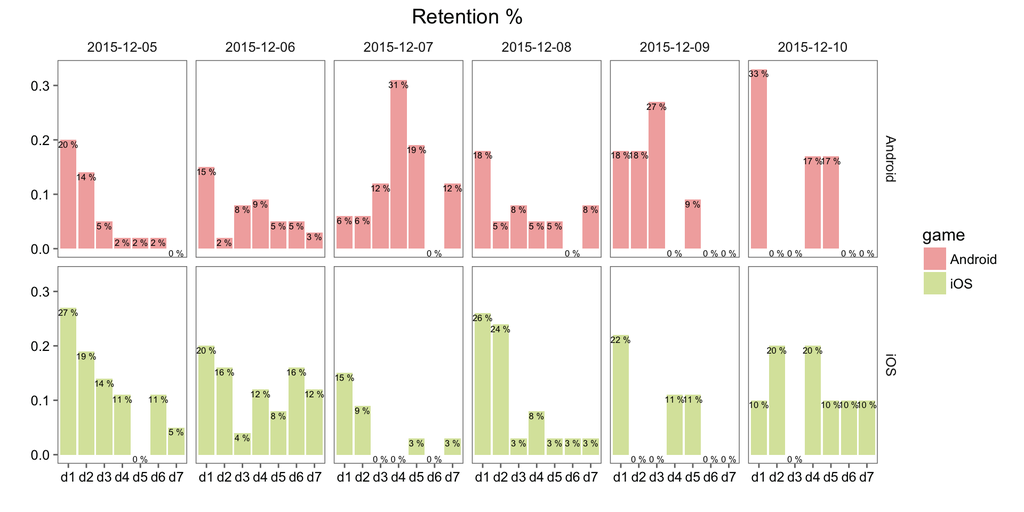

```r
#Bar plot
ggplot(retention.by.platform.plot, aes(x = day, y = retention, fill = game, label = paste(100*(retention), '%'))) +
  geom_bar(stat = "identity") +
  facet_grid(game~installed) +
  theme_few() +
  scale_fill_few() +
  ggtitle("Retention %") +
  geom_text(size = 2.2, vjust = 1.2) +
  ylab("") +
  xlab("")
```

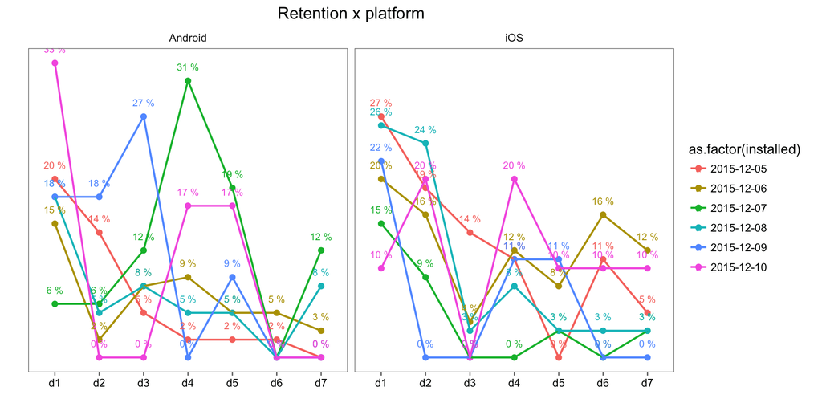

```r
#Line graph
ggplot(retention.by.platform.plot, aes(x = day, y = retention, color = as.factor(installed), label = paste(100*retention, '%'), group = installed)) +
  geom_point(size = 2) +
  geom_line(size = .8) +
  theme_few() +
  scale_fill_few() +
  facet_grid(~game) +
  geom_text(size = 3, vjust = -1.5) +
  ggtitle("Retention x platform") +
  ylab("") +
  xlab("") +
  theme(
    axis.ticks.y = element_blank(),
    axis.text.y = element_blank()
  )
```

# 4 Tutorial bounce

When users start the game they have to go through the tutorial. A drop off during the tutorial represents issues with the tutorial. Maybe a step is too long, confusing, or should be taken out entirely.

Using the event column let’s take any item that has the word ‘tutorial’

```r
#Extract
tutorial.bounce <-
run %>%
  filter(grepl("tutorial", event))
```

Due to the last implementation of tutorial, there are mirror event names that were used previously but thrown away. We will filter these out with the count number as future builds of the games will no longer use this.

```r
#Line
tutorial.bounce.l <-
  tutorial.bounce %>%
  group_by(event) %>%
  mutate(
    count = n()
  ) %>%
  distinct(event) %>%
  filter(count >50)

tutorial.bounce.l
```

```
## Source: local data frame [13 x 9]
## Groups: event [13]
##
##    app_version   game   type                   event  user       date
##         (fctr) (fctr) (fctr)                  (fctr) (int)     (date)
## 1        1.0.9    iOS  event          tutorial.start 48719 2015-12-04
## 2        1.0.9    iOS  event            tutorial.end 48719 2015-12-04
## 3        1.0.9    iOS  event   tutorial.startingline 48719 2015-12-04
## 4        1.0.9    iOS  event     tutorial.switchlane 47834 2015-12-04
## 5        1.0.9    iOS  event           tutorial.jump 47834 2015-12-04
## 6        1.0.9    iOS  event          tutorial.slide 47834 2015-12-04
## 7        1.0.9    iOS  event         tutorial.corner 47834 2015-12-04
## 8        1.0.9    iOS  event         tutorial.magnet 47834 2015-12-04
## 9        1.0.9    iOS  event tutorial.invincibillity 47834 2015-12-04
## 10       1.0.9    iOS  event      tutorial.bonusmode 47834 2015-12-04
## 11       1.0.9    iOS  event        tutorial.wallrun 47834 2015-12-04
## 12       1.0.9    iOS  event         tutorial.sprint 47834 2015-12-04
## 13       1.0.9    iOS  event           tutorial.free 47834 2015-12-04
## Variables not shown: time (chr), installed (date), count (int)
```

We need to columns that represent how many users started each step, how many finished it, and how many users left.

```r
#Create remaining, and bouncing users
tutorial.bounce.l <-
tutorial.bounce.l %>%
  ungroup() %>%
  arrange(desc(count)) %>%
  mutate(
    remaining = lead(count),
    remaining.p = lag(round(remaining / 475, 2)),
    bounce.p = 1 - remaining.p
  ) %>%
  select(event, count, remaining, remaining.p, bounce.p)

tutorial.bounce.l
```

```
## Source: local data frame [13 x 5]
##
##                      event count remaining remaining.p bounce.p
##                     (fctr) (int)     (int)       (dbl)    (dbl)
## 1           tutorial.start   475       433          NA       NA
## 2    tutorial.startingline   433       427        0.91     0.09
## 3      tutorial.switchlane   427       420        0.90     0.10
## 4            tutorial.jump   420       416        0.88     0.12
## 5           tutorial.slide   416       409        0.88     0.12
## 6          tutorial.corner   409       386        0.86     0.14
## 7          tutorial.magnet   386       383        0.81     0.19
## 8  tutorial.invincibillity   383       369        0.81     0.19
## 9       tutorial.bonusmode   369       359        0.78     0.22
## 10        tutorial.wallrun   359       347        0.76     0.24
## 11         tutorial.sprint   347       343        0.73     0.27
## 12            tutorial.end   343       324        0.72     0.28
## 13           tutorial.free   324        NA        0.68     0.32
```

Due to using lag, there are a couple of NA’s. We can easily replace these with the appropriate 1 and 0.

```r
#Fill in NAs with 100% and 0
tutorial.bounce.l$bounce.p[is.na(tutorial.bounce.l$bounce.p)] <- 0
tutorial.bounce.l$remaining.p[is.na(tutorial.bounce.l$remaining.p)] <- 1
```

Let’s plot~

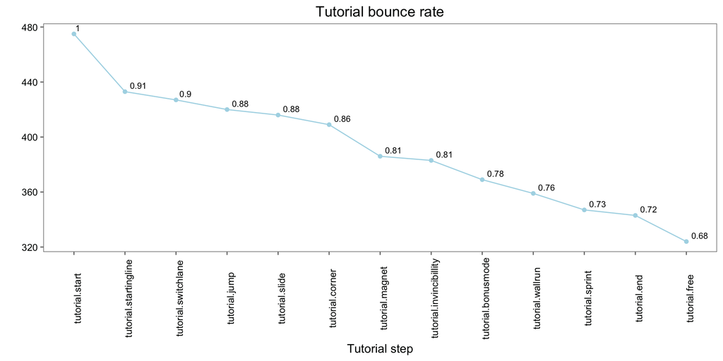

```r
#Line plot with remaining percentages as labels
ggplot(tutorial.bounce.l, aes(x = reorder(event, -count), y = count, label = remaining.p)) +
  geom_point(size = 1.5, color = "light blue") +
  geom_line(group = 1, color = "light blue ") +
  theme_few() +
  geom_text(size = 3, hjust = -.3, vjust = -.5) +
  theme(
    axis.text.x = element_text(angle = 90)
  ) +
  ggtitle("Tutorial bounce rate") +
  ylab("") +
  xlab("Tutorial step")
```

There is a 32% drop off from the beginning to the end of the tutorial. There are clear dropoffs between tutorial.start and tutorial.startingline 9%!

# 5 Conclusion

With more information we can create multiple cohorts to explore user data. Some that come to mind are:

- PU vs non paying
- Whales vs one time spenders
- Balance issues
- A/B comparisons
- Improvements to KPI for events, updates, etc